# R Markdown Basics

Aria Fu

2026-06-16

## Markdown

A widely used formatting language: Github, Jupyter notebook.

A simple way to format text using plain characters — `##` makes a heading, `**bold**` makes **bold**, backticks make code. No clicking buttons like in Word.

## Types of Chunks

An (optional) header surrounded by `---`

text mixed with simple text formatting

R code chunks surrounded by `` ``` ``

### Code Chunk

Keyboard shortcuts: `Cmd+Option+I` (Mac) or `Ctrl+Alt+I` (Windows)

#### Code Chunk Options

- `include = FALSE` prevents code and results from appearing in the finished file. R Markdown still runs the code in the chunk, and the results can be used by other chunks.
- `echo = FALSE` prevents code, but not the results from appearing in the finished file. This is a useful way to embed figures.
- `message = FALSE` prevents messages that are generated by code from appearing in the finished file.
- `warning = FALSE` prevents warnings that are generated by code from appearing in the finished.
- `eval = FALSE` Show code but don’t run it

## Review of Factor Data Structure

```r
race <- c("White", "Asian", "Hispanic", "Black")
race_obs <- c("White", "Asian", "Hispanic", "Black", "Hispanic", "Black", "Asian", "Asian")
race_obs_f <- factor(race_obs)

print(race_obs)
```

```
## [1] "White"    "Asian"    "Hispanic" "Black"    "Hispanic" "Black"    "Asian"
## [8] "Asian"
```

```r
print(levels(race_obs_f))
```

```
## [1] "Asian"    "Black"    "Hispanic" "White"
```

```r
print(race_obs_f)
```

```
## [1] White    Asian    Hispanic Black    Hispanic Black    Asian    Asian
## Levels: Asian Black Hispanic White
```

## Functions

A function is just a reusable piece of code that takes something in, does something to it, and gives something back.

```r
mean(x = c(1, 2, 3, 4, 5))
```

```
## [1] 3
```

- `mean` — the function name
- `()` — the parentheses are where you pass things in
- `x = c(1,2,3,4,5)` — the argument, the input you’re giving it

#### Build your own function

```r
my_function <- function(argument) {
  # do something
  return(result)
}
```

```r
rectangle_area <- function(width, height) {
  area <- width * height
  return(area)
}

rectangle_area(5, 10)
```

```
## [1] 50
```

```r
rectangle_area(height = 10, width = 5)
```

```
## [1] 50
```

```r
rec_area <- rectangle_area(6, 12)
rec_area
```

```
## [1] 72
```

## If-else

#### Basic Structure

```r
if (condition) {
  # do this if TRUE
} else {
  # do this if FALSE
}
```

Simple example

```r
x <- 10

if (x > 5) {
  print("x is greater than 5")
} else {
  print("x is 5 or less")
}
```

```
## [1] "x is greater than 5"
```

## R Packages

A package is a collection of functions someone else wrote and shared, so you don’t have to build everything from scratch. There are over 20,000 packages on CRAN (R’s official package repository) covering everything from data cleaning to machine learning to making maps.

#### Install Packages

```r
# install.packages("dplyr")   # downloads it once
library(dplyr)   # loads it for this session
```

## Use dplyr to do data manipulation

`dplyr` pipeline:

`dplyr` makes data manipulation in R read almost like plain English. Instead of nesting square brackets like in base R, we chain together simple verbs using the pipe `|>` or `%>%` The five core verbs are `filter()` (keep rows), `select()` (keep columns), `mutate()` (add or change a column), `arrange()` (sort rows), and `summarise()` (collapse rows into summary statistics, usually paired with `group_by()`). Each step in the pipeline takes the output of the previous step as its input, so a full pipeline reads top to bottom like a sentence describing exactly what’s being done to the data.

Note: You may have seen %>% in older tutorials (from the magrittr package). The native pipe `|>` was added in R 4.1 and behaves identically for most use cases. Either is fine; `|>` is the modern default.

#### Read Data

```r
mtcars1 <- readRDS("/Users/yubofu/Desktop/USC Course/LAbest_2026/mtcars1.rds")

# mtcars2 <- readRDS("mtcars2.rds")

mtcars3 <- read.csv("mtcars.csv") # read CSV file
```

##### `filter()` function for selecting rows

```r
cyl4 <- filter(mtcars, cyl == 4) # filter rows with cyl=4
head(cyl4)
```

```
##                 mpg cyl  disp hp drat    wt  qsec vs am gear carb
## Datsun 710     22.8   4 108.0 93 3.85 2.320 18.61  1  1    4    1
## Merc 240D      24.4   4 146.7 62 3.69 3.190 20.00  1  0    4    2
## Merc 230       22.8   4 140.8 95 3.92 3.150 22.90  1  0    4    2
## Fiat 128       32.4   4  78.7 66 4.08 2.200 19.47  1  1    4    1
## Honda Civic    30.4   4  75.7 52 4.93 1.615 18.52  1  1    4    2
## Toyota Corolla 33.9   4  71.1 65 4.22 1.835 19.90  1  1    4    1
```

```r
# Multiple conditions — use comma (AND) or | (OR)
cyl4_mpg25 <- filter(mtcars, cyl == 4, mpg > 25)
cyl4_or_mpg25 <- filter(mtcars, cyl == 4 | mpg > 25)
```

##### `select()`: select columns

```r
# pick only the columns we care about
subdata1 <- select(mtcars, mpg, cyl, hp, wt)

# drop a column with minus sign
subdata2 <- select(mtcars, -qsec, -vs)
```

##### `mutate()`: add / change columns

```r
data3 <- mutate(mtcars, kpl = mpg * 0.425) # create a new dataset with additional kpl col
head(data3)
```

```
##                    mpg cyl disp  hp drat    wt  qsec vs am gear carb    kpl
## Mazda RX4         21.0   6  160 110 3.90 2.620 16.46  0  1    4    4 8.9250
## Mazda RX4 Wag     21.0   6  160 110 3.90 2.875 17.02  0  1    4    4 8.9250
## Datsun 710        22.8   4  108  93 3.85 2.320 18.61  1  1    4    1 9.6900
## Hornet 4 Drive    21.4   6  258 110 3.08 3.215 19.44  1  0    3    1 9.0950
## Hornet Sportabout 18.7   8  360 175 3.15 3.440 17.02  0  0    3    2 7.9475
## Valiant           18.1   6  225 105 2.76 3.460 20.22  1  0    3    1 7.6925
```

```r
mtcars %>%
  mutate(kpl = mpg * 0.425,
         cyl_f = factor(cyl)
         )  %>%
  select(mpg, cyl_f, kpl) %>%
  head()
```

```
##                    mpg cyl_f    kpl
## Mazda RX4         21.0     6 8.9250
## Mazda RX4 Wag     21.0     6 8.9250
## Datsun 710        22.8     4 9.6900
## Hornet 4 Drive    21.4     6 9.0950
## Hornet Sportabout 18.7     8 7.9475
## Valiant           18.1     6 7.6925
```

##### Rename columns

```r
# rename multiple columns: rename(new_name = old_name)
mtcars %>%
  rename(
  miles_per_gallon = mpg,
  horsepower  = hp
    )
```

```
##                     miles_per_gallon cyl  disp horsepower drat    wt  qsec vs
## Mazda RX4                       21.0   6 160.0        110 3.90 2.620 16.46  0
## Mazda RX4 Wag                   21.0   6 160.0        110 3.90 2.875 17.02  0
## Datsun 710                      22.8   4 108.0         93 3.85 2.320 18.61  1
## Hornet 4 Drive                  21.4   6 258.0        110 3.08 3.215 19.44  1
## Hornet Sportabout               18.7   8 360.0        175 3.15 3.440 17.02  0
## Valiant                         18.1   6 225.0        105 2.76 3.460 20.22  1
## Duster 360                      14.3   8 360.0        245 3.21 3.570 15.84  0
## Merc 240D                       24.4   4 146.7         62 3.69 3.190 20.00  1
## Merc 230                        22.8   4 140.8         95 3.92 3.150 22.90  1
## Merc 280                        19.2   6 167.6        123 3.92 3.440 18.30  1
## Merc 280C                       17.8   6 167.6        123 3.92 3.440 18.90  1
## Merc 450SE                      16.4   8 275.8        180 3.07 4.070 17.40  0
## Merc 450SL                      17.3   8 275.8        180 3.07 3.730 17.60  0
## Merc 450SLC                     15.2   8 275.8        180 3.07 3.780 18.00  0
## Cadillac Fleetwood              10.4   8 472.0        205 2.93 5.250 17.98  0
## Lincoln Continental             10.4   8 460.0        215 3.00 5.424 17.82  0
## Chrysler Imperial               14.7   8 440.0        230 3.23 5.345 17.42  0
## Fiat 128                        32.4   4  78.7         66 4.08 2.200 19.47  1
## Honda Civic                     30.4   4  75.7         52 4.93 1.615 18.52  1
## Toyota Corolla                  33.9   4  71.1         65 4.22 1.835 19.90  1
## Toyota Corona                   21.5   4 120.1         97 3.70 2.465 20.01  1
## Dodge Challenger                15.5   8 318.0        150 2.76 3.520 16.87  0
## AMC Javelin                     15.2   8 304.0        150 3.15 3.435 17.30  0
## Camaro Z28                      13.3   8 350.0        245 3.73 3.840 15.41  0
## Pontiac Firebird                19.2   8 400.0        175 3.08 3.845 17.05  0
## Fiat X1-9                       27.3   4  79.0         66 4.08 1.935 18.90  1
## Porsche 914-2                   26.0   4 120.3         91 4.43 2.140 16.70  0
## Lotus Europa                    30.4   4  95.1        113 3.77 1.513 16.90  1
## Ford Pantera L                  15.8   8 351.0        264 4.22 3.170 14.50  0
## Ferrari Dino                    19.7   6 145.0        175 3.62 2.770 15.50  0
## Maserati Bora                   15.0   8 301.0        335 3.54 3.570 14.60  0
## Volvo 142E                      21.4   4 121.0        109 4.11 2.780 18.60  1
##                     am gear carb
## Mazda RX4            1    4    4
## Mazda RX4 Wag        1    4    4
## Datsun 710           1    4    1
## Hornet 4 Drive       0    3    1
## Hornet Sportabout    0    3    2
## Valiant              0    3    1
```

[output cut: 11 more lines]

```
## Fiat 128             1    4    1
## Honda Civic          1    4    2
## Toyota Corolla       1    4    1
## Toyota Corona        0    3    1
## Dodge Challenger     0    3    2
## AMC Javelin          0    3    2
## Camaro Z28           0    3    4
## Pontiac Firebird     0    3    2
## Fiat X1-9            1    4    1
## Porsche 914-2        1    5    2
## Lotus Europa         1    5    2
## Ford Pantera L       1    5    4
## Ferrari Dino         1    5    6
## Maserati Bora        1    5    8
## Volvo 142E           1    4    2
```

##### Order Rows

```r
## arrange() — sort rows
# Sort by mpg, ascending (default)
mtcars |>
  arrange(mpg) |>
  head()
```

```
##                      mpg cyl disp  hp drat    wt  qsec vs am gear carb
## Cadillac Fleetwood  10.4   8  472 205 2.93 5.250 17.98  0  0    3    4
## Lincoln Continental 10.4   8  460 215 3.00 5.424 17.82  0  0    3    4
## Camaro Z28          13.3   8  350 245 3.73 3.840 15.41  0  0    3    4
## Duster 360          14.3   8  360 245 3.21 3.570 15.84  0  0    3    4
## Chrysler Imperial   14.7   8  440 230 3.23 5.345 17.42  0  0    3    4
## Maserati Bora       15.0   8  301 335 3.54 3.570 14.60  0  1    5    8
```

```r
# Descending: wrap with desc()
mtcars |>
  arrange(desc(mpg)) |>
  head()
```

```
##                 mpg cyl  disp  hp drat    wt  qsec vs am gear carb
## Toyota Corolla 33.9   4  71.1  65 4.22 1.835 19.90  1  1    4    1
## Fiat 128       32.4   4  78.7  66 4.08 2.200 19.47  1  1    4    1
## Honda Civic    30.4   4  75.7  52 4.93 1.615 18.52  1  1    4    2
## Lotus Europa   30.4   4  95.1 113 3.77 1.513 16.90  1  1    5    2
## Fiat X1-9      27.3   4  79.0  66 4.08 1.935 18.90  1  1    4    1
## Porsche 914-2  26.0   4 120.3  91 4.43 2.140 16.70  0  1    5    2
```

##### summarise() + group_by()

```r
# Average mpg across all cars
mtcars  %>%
  summarise(avg_mpg = mean(mpg))
```

```
##    avg_mpg
## 1 20.09062
```

```r
# Average mpg BY cylinder group — this is the power combo
mtcars %>%
  group_by(cyl) %>%
  summarise( avg_mpg = mean(mpg),
             count = n()
            )
```

```
## # A tibble: 3 × 3
##     cyl avg_mpg count
##   <dbl>   <dbl> <int>
## 1     4    26.7    11
## 2     6    19.7     7
## 3     8    15.1    14
```

```r
best_auto <- mtcars |>
  filter(am == 1) |> # automatic only
  select(mpg, cyl, hp, wt) |> # keep relevant columns
  mutate(kpl = mpg * 0.425) |> # add kpl
  arrange(desc(mpg))

head(best_auto)
```

```
##                 mpg cyl  hp    wt     kpl
## Toyota Corolla 33.9   4  65 1.835 14.4075
## Fiat 128       32.4   4  66 2.200 13.7700
## Honda Civic    30.4   4  52 1.615 12.9200
## Lotus Europa   30.4   4 113 1.513 12.9200
## Fiat X1-9      27.3   4  66 1.935 11.6025
## Porsche 914-2  26.0   4  91 2.140 11.0500
```

## Plotting

#### Basic plotting

Quick & useful for a fast look at you data

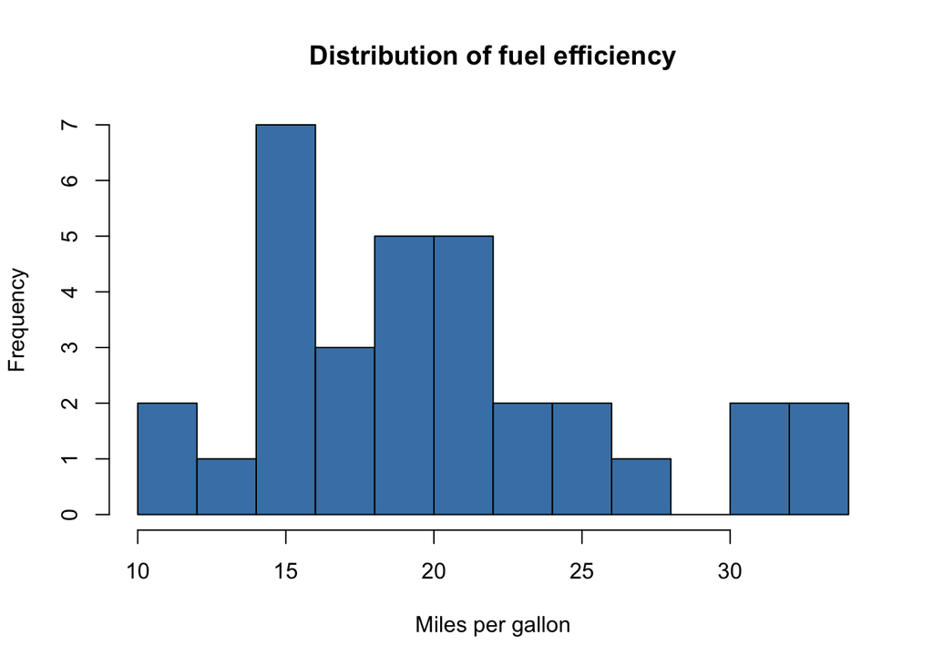

```r
# Histogram: distribution of mpg
hist(mtcars$mpg,
     main = "Distribution of fuel efficiency",
     xlab = "Miles per gallon",
     col = "steelblue",
     breaks = 10)
```

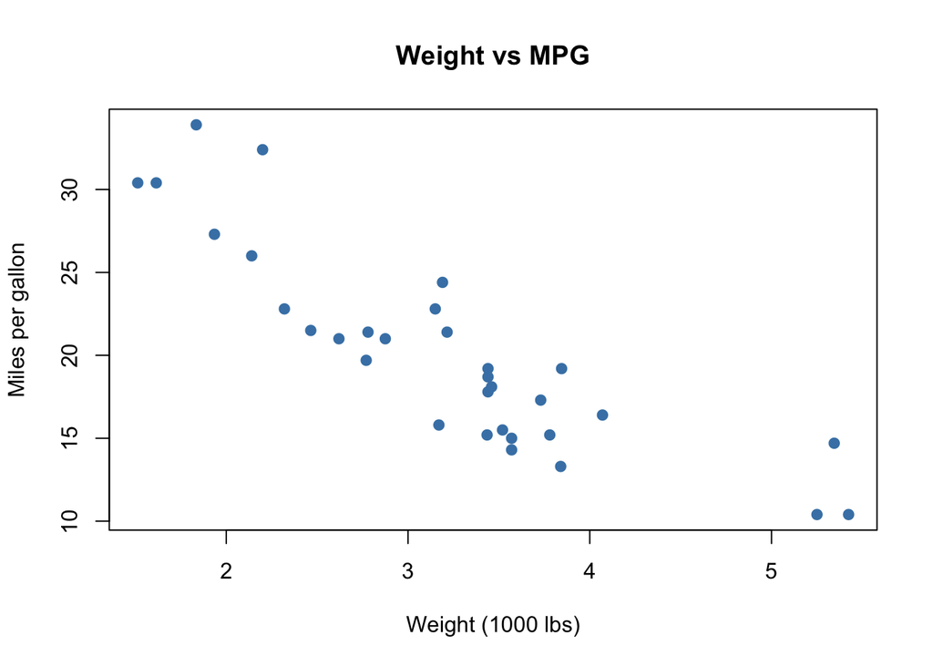

```r
# Scatter plot: weight vs mpg
plot(mtcars$wt, mtcars$mpg,
     main = "Weight vs MPG",
     xlab = "Weight (1000 lbs)",
     ylab = "Miles per gallon",
     pch = 19,
     col = "steelblue")
```

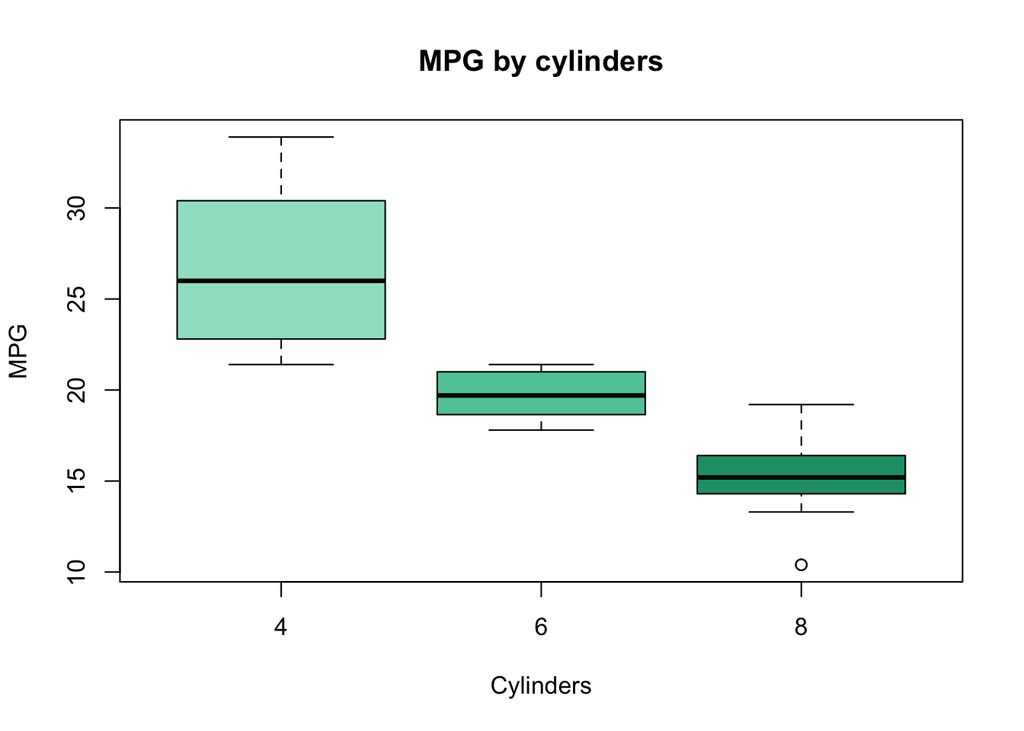

```r
# Boxplot: mpg by cylinder count
boxplot(mpg ~ cyl, data = mtcars,
        main = "MPG by cylinders",
        xlab = "Cylinders",
        ylab = "MPG",
        col = c("#9FE1CB", "#5DCAA5", "#1D9E75")
        )
```

#### ggplot: making publication quality graphics. (reports, journal papers)

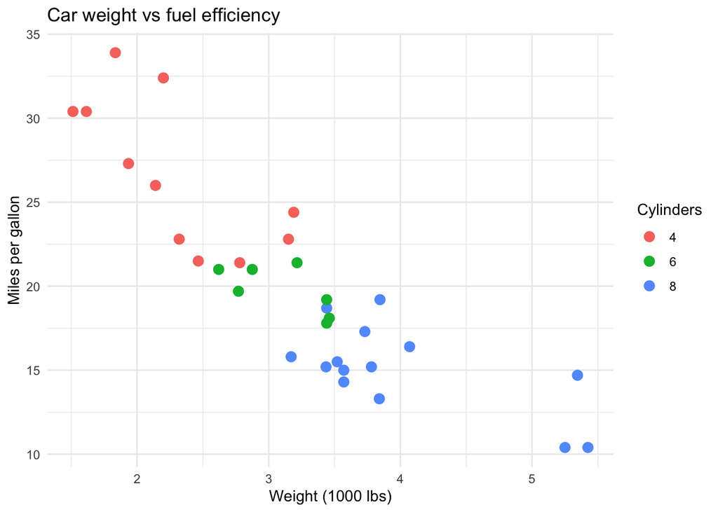

```r
# install.packages("ggplot2")
library(ggplot2)

# ggplot works in layers: data → aesthetics → geometry
ggplot(mtcars,
       aes(x = wt, y = mpg, color = factor(cyl))
       ) +
  geom_point(size = 3) +
  labs( title = "Car weight vs fuel efficiency",
        x = "Weight (1000 lbs)",
        y = "Miles per gallon",
        color = "Cylinders"
        ) +
  theme_minimal()
```